# M10 Data Analysis - Putting it Together

Benjamin Panny

12/16/2021

# 1 Effect of treatment on preterm birth

## 1.1 A Numerical and Visual Summary

```r
#numerical summary of preterm status within groups
kableExtra::kable(xtabs(~ Group + Preterm, data=opt) %>% prop.table(margin = 1) %>% round(4), caption = "Proportion of preterm birth status by group", "simple")
```

Proportion of preterm birth status by group

|  | N | Y |
| --- | --- | --- |
| Control | 0.9028 | 0.0972 |
| Treatment | 0.8905 | 0.1095 |

```r
by_group <- group_by(opt, Group)
count(by_group, Preterm)
```

| Group | Preterm | n |
| --- | --- | --- |
| Control | N | 353 |
| Control | Y | 38 |
| Control | NA | 19 |
| Treatment | N | 358 |
| Treatment | Y | 44 |
| Treatment | NA | 11 |

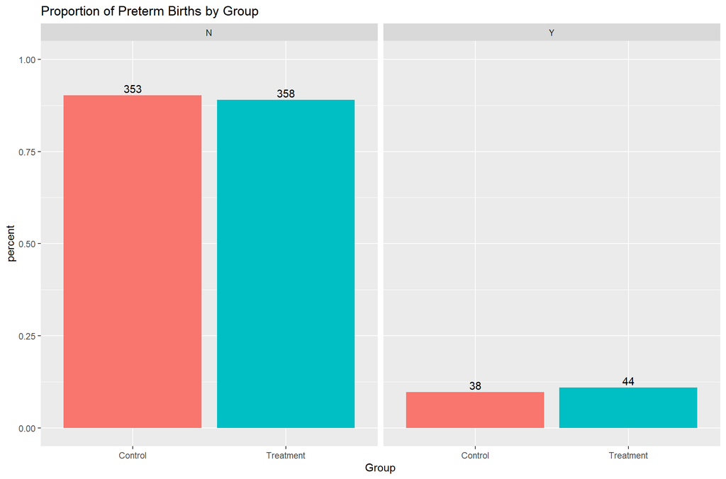

```r
#Visualization of relationship between preterm birth and treatment group
plot_data <- opt %>% drop_na(Group, Preterm) %>%
  group_by(Group, Preterm) %>%
  tally %>%
  mutate(percent = n/sum(n))
ggplot(data = plot_data, aes(x = Group, y = percent)) +
  geom_bar(stat="identity", aes(fill = Group)) +
  theme(legend.position = "none") + # suppress legend
  scale_y_continuous(limits=c(0,1)) + # force y-axis to be 0-1
  facet_wrap(. ~ Preterm) +  # separate by var2
  geom_text(aes(label = n), vjust = -0.3) + # add counts as text
  ggtitle("Proportion of Preterm Births by Group")
```

Perform a hypothesis test to examine if there is an association between preterm birth and treatment group. Using this information, write a conclusion about the relationship between preterm birth and treatment group (including an interpretation of the relevant odds ratio).

## 1.2 A two-sample Z-test of proportions: Hypotheses and Conditions

To determine whether there is an association between preterm birth and treatment group, we use a two-sample Z-test. The null hypothesis for this test is that the population proportion difference between the two groups is zero, while the alternative hypothesis for this test is that the population proportion difference between the two groups is nonzero

The conditions for this test are met: we assume the two groups form two simple random samples and that they are independent and unrelated. As shown in the numerical summary of this section, successes and failures are greater than five in both samples.

## 1.3 Two-sample Z-test: P-Value with Interpretation

After removing observations with missing data, the chi-squared value for a 2-sample Z-test for equality of proportions without continuity correction is .3216 - indicating observed proportions not far from expectation. The p-value for this test statistic is .5706, indicating a 57.06% chance of observing the results we do if the population proportions of preterm births of each group are the same and preterm birth is not associated with group.

```r
prop.test(x = c(38,44),n=c(353+38,358+44), correct=FALSE)
```

```
##
##  2-sample test for equality of proportions without continuity
##  correction
##
## data:  c(38, 44) out of c(353 + 38, 358 + 44)
## X-squared = 0.32166, df = 1, p-value = 0.5706
## alternative hypothesis: two.sided
## 95 percent confidence interval:
##  -0.05461543  0.03008336
## sample estimates:
##    prop 1    prop 2
## 0.0971867 0.1094527
```

```r
orcont <- .0972/.9028
ortmt <- .1095/.8905
orcont
```

```
## [1] 0.107665
```

```r
ortmt
```

```
## [1] 0.1229646
```

```r
or <- ortmt/orcont
or
```

```
## [1] 1.142104
```

## 1.4 Statistical Decision and Conclusion in Context

Due to a nonstatistically significant p-value for a two-sample z-test, we fail to reject our null hypothesis. We have no evidence to suggest there is an association between treatment group and preterm birth status, as measured by the difference in proportions of preterm births between groups. This insignificant test result indicates taking the odds ratio of 1.14 between the treatment group and control group with a grain of salt. That is, that the treatment group was associated with higher odds of preterm birth than the control group in our sample, but this odds ratio was not statistically significant when tested.

# 2 Effect of age on preterm birth

## 2.1 Numerical and Visual Summary

```r
#numerical summary of preterm birth and age
kableExtra::kable(opt %>% group_by(Preterm) %>%
  summarize(N = n(),
            Mean = mean(Age, na.rm=TRUE),
            SD = sd(Age, na.rm=TRUE),
            Median = median(Age, na.rm=TRUE),
            IQR = quantile(Age, 0.75, na.rm=TRUE)-quantile(Age, 0.25, na.rm=TRUE),
            Min = min(Age, na.rm=TRUE),
            Max = max(Age, na.rm=TRUE)), digits = 2, "simple", caption = "Age Distribution By Preterm Birth Status")
```

Age Distribution By Preterm Birth Status

| Preterm | N | Mean | SD | Median | IQR | Min | Max |
| --- | --- | --- | --- | --- | --- | --- | --- |
| N | 711 | 25.82 | 5.49 | 25 | 7.50 | 16 | 44 |
| Y | 82 | 27.55 | 6.10 | 27 | 8.75 | 18 | 44 |
| NA | 30 | 25.43 | 5.22 | 24 | 6.00 | 17 | 39 |

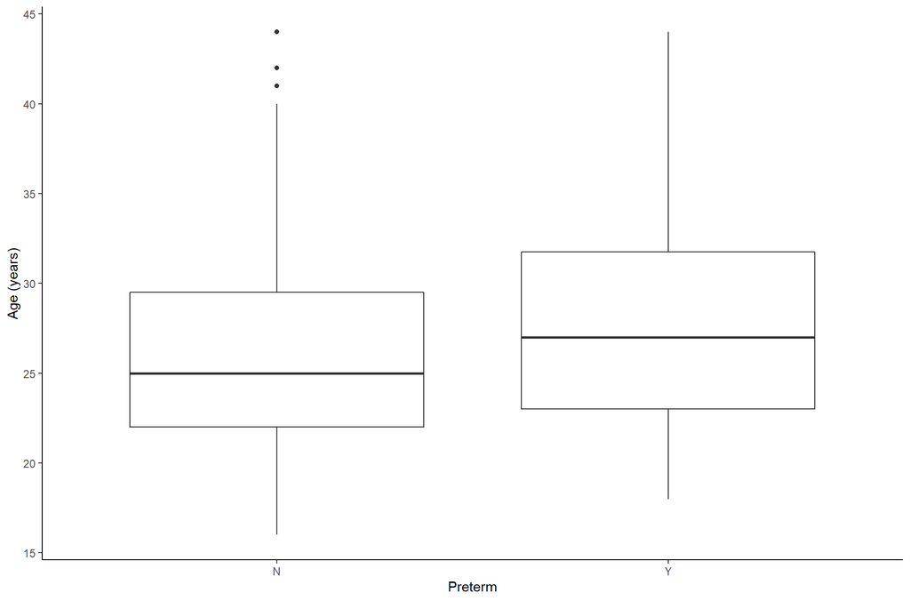

```r
#visualization to examine relationship between
#preterm birth and maternal age
ggplot(opt %>% drop_na(Preterm, Age), aes(y=Age, x=Preterm)) + geom_boxplot() +
  theme_classic() + ylab("Age (years)")
```

```r
#calc difference in mean age between preterm and normal term
mean_age_pt = mean(filter(opt, Preterm == "Y")$Age)
mean_age_nt = mean(filter(opt, Preterm == "N")$Age)
mean_age_term_diff = abs(mean_age_pt - mean_age_nt)
```

## 2.2 Null and Alternative Hypotheses

The Null Hypothesis is that there is no difference in the true population mean age for those in the who do and do not have preterm births. The alternative hypothesis is that there is a difference in the true population mean age for those in who do and do not have preterm births.

Given that we want to use an independent samples t-test, but are unsure of whether the variances of our samples are equal or not, we will perform an F test for equality of variances. The null hypothesis for this test is that the variances are equal. The alternative hypothesis is that they are not equal.

## 2.3 Conditions for an F test for equality of variances and the F statistic and p-value with interpretation

We will assume the sample is a simple random sample from the two populations of those who do and do not have preterm births. We also know the two groups are independent (Preterm Birth Status categories are mutually exclusive). The outcome data of Age in years is also normal.

```r
topt <- as.tibble(opt) %>% drop_na()
```

[figure not shown]

```r
qqnorm(topt$Age, ylab = "Headache Severity Score Difference")
qqline(topt$Age)
```

```r
var.test(Age ~ Preterm, data = topt, alternative = "two.sided", conf.level = 0.95)
```

```
##
##  F test to compare two variances
##
## data:  Age by Preterm
## F = 0.91747, num df = 646, denom df = 74, p-value = 0.5841
## alternative hypothesis: true ratio of variances is not equal to 1
## 95 percent confidence interval:
##  0.6364088 1.2620050
## sample estimates:
## ratio of variances
##          0.9174666
```

The F statistic for the F test for equality of variances is .91747, indicating the ratio of the variances of those who did and did not give preterm birth. The p-value of .5841 indicates a 58.41% chance of observing this variance ratio if the true ratio is equal to 1. Therefore, we do not reject the null hypothesis that the variances are equal - we have no evidence to support the alternative.

## 2.4 Conditions for Two sample T-Test with Equal Variances

We assume a simple random sample from the two populations (those who do and do not give births). We also assume our 2 groups are independent (no spouses, siblings, etc.). We have more than 30 observations for each group. We tested the equal variances assumption in the last section

## 2.5 Two sample T-statistic, P-Value, and Confidence Interval with Interpretation

The two-sided two sample t statistic for equal variances that we observe is -2.1478, indicating a larger mean age in the preterm group compared to the mean age in the non-preterm group. The p-value was .0321, which indicates a less than 3.21% chance of observing the difference in means we observed if the true difference is 0.

The two-sided 95% confidence interval for the between group mean differences is (-2.778 -.124). This is to say that if we repeated the same procedures, the interval given by the data would capture the true difference between groups 95% of the time and we are therefore 95% confident that the true difference is between -2.778 and -.124.

```r
t.test(topt$Age~ topt$Preterm, var.equal = TRUE, alternative = "two.sided", conf.level=0.95)
```

```
##
##  Two Sample t-test
##
## data:  topt$Age by topt$Preterm
## t = -2.1478, df = 720, p-value = 0.03206
## alternative hypothesis: true difference in means is not equal to 0
## 95 percent confidence interval:
##  -2.7779993 -0.1247107
## sample estimates:
## mean in group N mean in group Y
##        25.76198        27.21333
```

Create an appropriate visualization and numerical summary to examine the relationship between preterm birth and pregnant individual’s age. Perform a hypothesis test to examine if there is a significant difference in the mean (or median) age for those who did and did not end up delivering preterm. Using this information, write a conclusion about the relationship between age and preterm birth (including the difference in the estimated means/medians).

## 2.6 Statistical Decision and Conclusion in Context

Due to a statistically significant p-value, we reject the null hypothesis that the mean age of those who give preterm birth and those who give non-preterm birth are the same. We have evidence to suggest there is a difference in mean age between these groups. Specifically, our results suggest this difference is driven in the population by the fact that those who give preterm births tend to be older on average than those who give non-preterm birth.

# 3 Effect of age on infant birthweight

## 3.1 Numerical and Visual Summary

```r
#numerical - birthweight and age correlation
age_bw_cor = cor(opt$Age, opt$Birthweight, use="pairwise.complete.obs")
age_bw_cor
```

```
## [1] 0.03810462
```

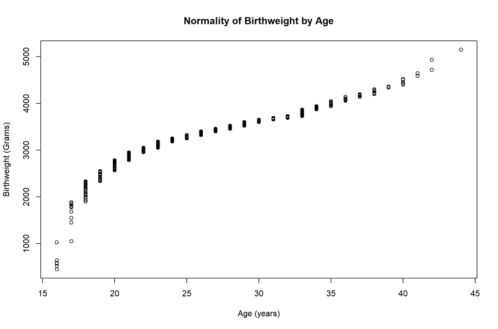

```r
qqplot(topt$Age, topt$Birthweight, ylab = "Birthweight (Grams)", xlab = "Age (years)", main = "Normality of Birthweight by Age")
qqline(topt$Birthweight)
```

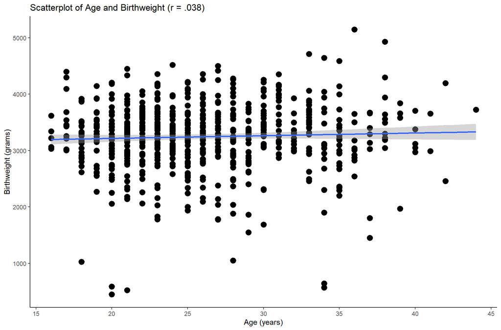

```r
topt %>%
  ggplot(aes(x = Age, y = Birthweight)) +
  geom_point(size=3, stroke=1) + ylab("Birthweight (grams)") + xlab("Age (years)") + ggtitle("Scatterplot of Age and Birthweight (r = .038)")+geom_smooth(method="lm") + theme_classic()
```

Create an appropriate visualization and numerical summary to examine the relationship between infant’s birthweight and pregnant individual’s age. Perform a hypothesis test to examine if there is a significant linear relationship between pregnant individual’s age (predictor) and infant’s birthweight (outcome). Using this information, write a conclusion about the relationship between age and birthweigth (including an estimated impact of age on birthweight).

We seek to estimate the change in the expected (average) value of birthweight (in grams) per one unit (year) increase in maternal age.

In our sample, we observe an intercept coefficient of 3120.5, indicating a average birthweight in grams 3120.5 if the mother is a 0 year old. However, this is not particularly useful since this extrapolates below any observed values for age in our dataset as well as the realm of possibility for maternal age. We also observed a Beta coefficient for Age of 4.797 This indicates a 4.797 gram increase in the expected value (average) of birthweight per one year increase in maternal age. The 95% confidence interval for this slope is (-2.82, 12.41). This is to say we are 95% confident our observed interval captures the true linear relationship (slope), a confidence level we derive from our random interval (constructed from our random sample) capturing the true parameter 95% of the time.

For the null hypothesis that the slope is equal to zero (and the alternative hypothesis it is not equal to zero), we observe a T-statistic of 1.237, indicating an estimated slope greater than the standard error of the estimate. We observe a p-value of .217, indicating a 21.7% chance of observing the slope we do if the true value is zero. Thus we do not have evidence to reject the null hypothesis.

The coefficient of determination for Age is .00212, indicating age explains .2% of the total variance in birthweight in our sample.

```r
model1 <- lm(Birthweight ~ Age, data=topt)
summary(model1)
```

```
##
## Call:
## lm(formula = Birthweight ~ Age, data = topt)
##
## Residuals:
##      Min       1Q   Median       3Q      Max
## -2766.43  -273.74    36.89   352.13  1856.83
##
## Coefficients:
##             Estimate Std. Error t value Pr(>|t|)
## (Intercept) 3120.492    102.780  30.361   <2e-16 ***
## Age            4.797      3.878   1.237    0.217
## ---
## Signif. codes:  0 '***' 0.001 '**' 0.01 '*' 0.05 '.' 0.1 ' ' 1
##
## Residual standard error: 578.4 on 720 degrees of freedom
## Multiple R-squared:  0.00212,    Adjusted R-squared:  0.000734
## F-statistic:  1.53 on 1 and 720 DF,  p-value: 0.2166
```

```r
confint(model1)
```

```
##                   2.5 %     97.5 %
## (Intercept) 2918.707418 3322.27741
## Age           -2.817718   12.41112
```

The average birthweight for 40 year-olds given our model is 3312.36 grams

```r
matrix_coef <- summary(lm(Birthweight ~ Age, data=topt))$coefficients #extract coef
my_estimates <- matrix_coef[ , 1] #extract estimates
as.numeric(my_estimates[2])*40+as.numeric(my_estimates[1])
```

```
## [1] 3312.36
```

## 3.3 Statistical Decision and Conclusion in Context

Due to a nonstatistically significant p-value for the slope between age and birthweight, we do not reject the null hypothesis that there is no linear relationship between age and birthweight. We do not have evidence to suggest that a nonzero linear relationship between age and birthweight exists. Given these statistical results, we conclude no relationship between birthweight and age.